# Spain

### Cài đặt thư viện mlxtend và xlrd

Sau khi cài đặt, import các thư viện cần thiết: thư viện máy học (mlxtend)

```python
import pandas as pd
import seaborn as sns
import matplotlib.pyplot as plt
%matplotlib inline
from mlxtend.frequent_patterns import apriori
from mlxtend.frequent_patterns import association_rules
```

```python
with open('F:\DOWNLOAD\KHAI THAC DL\DATA\OR.csv') as f:
    df = pd.read_csv(f)
```

Sau khi dữ liệu được đọc vào biến df, hiển thị một vài thông tin của biến này

```python
df.info()
```

```
<class 'pandas.core.frame.DataFrame'>
RangeIndex: 541909 entries, 0 to 541908
Data columns (total 8 columns):
 #   Column       Non-Null Count   Dtype
---  ------       --------------   -----
 0   InvoiceNo    541909 non-null  object
 1   StockCode    541909 non-null  object
 2   Description  540455 non-null  object
 3   Quantity     541909 non-null  int64
 4   InvoiceDate  541909 non-null  object
 5   UnitPrice    541909 non-null  float64
 6   CustomerID   406829 non-null  float64
 7   Country      541909 non-null  object
dtypes: float64(2), int64(1), object(5)
memory usage: 33.1+ MB
```

### Loại bỏ ký tự thừa ở tên mặt hàng mua (Description), xóa các dòng dữ liệu không có số hóa đơn (cột Invoice No) và chuyển nó về kiểu dữ liệu chuỗi.

```python
df['Description'] = df['Description'].str.strip()
df.dropna(axis=0, subset=['InvoiceNo'], inplace=True)
df['InvoiceNo'] = df['InvoiceNo'].astype('str')
```

Xem thử 10 dòng đầu của dữ liệu sau khi đã thực hiện thao tác làm sạch

```python
df.head(10)
```

|  | InvoiceNo | StockCode | Description | Quantity | InvoiceDate | UnitPrice | CustomerID | Country |
| --- | --- | --- | --- | --- | --- | --- | --- | --- |
| 0 | 536365 | 85123A | WHITE HANGING HEART T-LIGHT HOLDER | 6 | 12/1/2010 8:26 | 2.55 | 17850.0 | United Kingdom |
| 1 | 536365 | 71053 | WHITE METAL LANTERN | 6 | 12/1/2010 8:26 | 3.39 | 17850.0 | United Kingdom |
| 2 | 536365 | 84406B | CREAM CUPID HEARTS COAT HANGER | 8 | 12/1/2010 8:26 | 2.75 | 17850.0 | United Kingdom |
| 3 | 536365 | 84029G | KNITTED UNION FLAG HOT WATER BOTTLE | 6 | 12/1/2010 8:26 | 3.39 | 17850.0 | United Kingdom |
| 4 | 536365 | 84029E | RED WOOLLY HOTTIE WHITE HEART. | 6 | 12/1/2010 8:26 | 3.39 | 17850.0 | United Kingdom |
| 5 | 536365 | 22752 | SET 7 BABUSHKA NESTING BOXES | 2 | 12/1/2010 8:26 | 7.65 | 17850.0 | United Kingdom |
| 6 | 536365 | 21730 | GLASS STAR FROSTED T-LIGHT HOLDER | 6 | 12/1/2010 8:26 | 4.25 | 17850.0 | United Kingdom |
| 7 | 536366 | 22633 | HAND WARMER UNION JACK | 6 | 12/1/2010 8:28 | 1.85 | 17850.0 | United Kingdom |
| 8 | 536366 | 22632 | HAND WARMER RED POLKA DOT | 6 | 12/1/2010 8:28 | 1.85 | 17850.0 | United Kingdom |
| 9 | 536367 | 84879 | ASSORTED COLOUR BIRD ORNAMENT | 32 | 12/1/2010 8:34 | 1.69 | 13047.0 | United Kingdom |

Có thể xem một ví dụ về loại hóa đơn tín dụng bằng câu lệnh sau

```python
df[df.InvoiceNo.str.contains('C', na=False)].head()
```

|  | InvoiceNo | StockCode | Description | Quantity | InvoiceDate | UnitPrice | CustomerID | Country |
| --- | --- | --- | --- | --- | --- | --- | --- | --- |
| 141 | C536379 | D | Discount | -1 | 12/1/2010 9:41 | 27.50 | 14527.0 | United Kingdom |
| 154 | C536383 | 35004C | SET OF 3 COLOURED FLYING DUCKS | -1 | 12/1/2010 9:49 | 4.65 | 15311.0 | United Kingdom |
| 235 | C536391 | 22556 | PLASTERS IN TIN CIRCUS PARADE | -12 | 12/1/2010 10:24 | 1.65 | 17548.0 | United Kingdom |
| 236 | C536391 | 21984 | PACK OF 12 PINK PAISLEY TISSUES | -24 | 12/1/2010 10:24 | 0.29 | 17548.0 | United Kingdom |
| 237 | C536391 | 21983 | PACK OF 12 BLUE PAISLEY TISSUES | -24 | 12/1/2010 10:24 | 0.29 | 17548.0 | United Kingdom |

Tiến hành xóa những hóa đơn tín dụng

```python
df=df[~df['InvoiceNo'].str.contains('C')]
```

### Thống kê dòng dữ liệu theo từng quốc gia

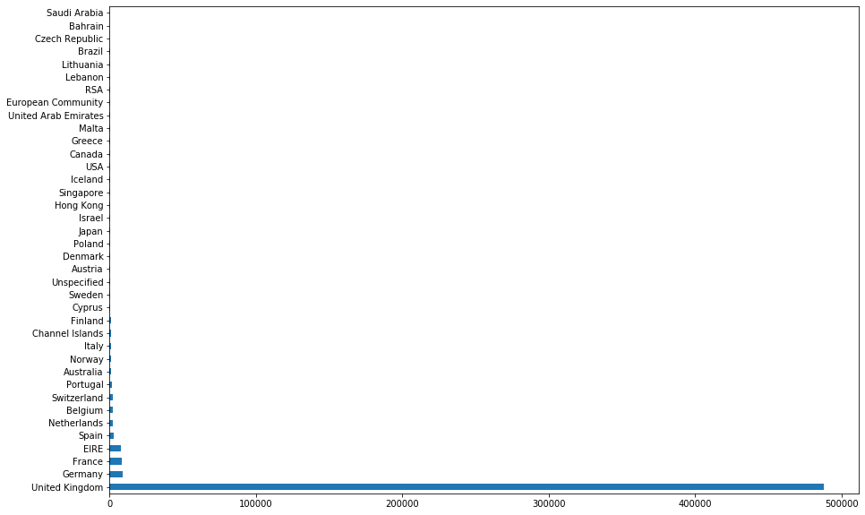

```python
df['Country'].value_counts().plot(kind='barh', figsize=(15,10))
```

```python
df = df[~df['Description'].str.contains('POSTAGE', na=False)]
```

Lấy ra dữ liệu hóa đơn từ nước Tây Ban Nha 'Spain' và chỉ lấy 2 cột là Tên mặt hàng (Description) và Ngày hóa đơn (InvoiceDate)

Thực hiện yêu cầu trên bằng câu lệnh sau:

```python
data = df[df['Country'] == "Spain"].loc[:,['Description','InvoiceDate']]
```

Tạo cột mới tên là 'Interval' có kiểu số nguyên. Cột này chứ giá trị là khoảng cách theo đơn vị ngày giữa các giá trị đến ngày hóa đơn (InvoiceDate) nhỏ nhất.

Trước hết, cần tìm ngày nhỏ nhất và lưu vào biến min_date

```python
min_date = data['InvoiceDate'].min()
min_date
```

```
'1/10/2011 9:11'
```

Trước tiên, ta cần import thư viện numpy vào môi trường

```python
import numpy as np
import datetime as dt
```

Các bước trên được thực hiện trong câu lệnh sau

```python
data['Interval'] = ((data['InvoiceDate'] - min_date)/np.datetime64(1, 'D')).astype('int')
```

[output not shown]

[output cut: 11 more lines]

[output not shown]

Xem kết quả tạo cột Interval

```python
data.info()
```

[output not shown]

Một vài giá trị hiện tại trong dữ liệu

```python
data.head(10)
```

[output not shown]

Tạo chuỗi dữ liệu đầu vào đúng với yêu cầu của thư viện. Đầu vào của thư viện này là một danh sách (list) các bộ (tuple). Với mỗi bộ có giá trị là thời gian (cột Interval) và tên mặt hàng mua (cột Description)

Import thư viện Episode Mining

```python
import EpisodeMining as em
```

Tạo biến sequence là chuỗi dữ liệu phù hợp yêu cầu của thưu viện

```python
sequence = list(data.loc[:,['Interval','Description']].to_records(index=False))
```

Tiến hành khai báo thuật toán với các thông số theo yêu cầu đề bài

```python
from episode_mining.winepi import WINEPI, WinEpiRules
w = WinEpi(sequence, episode_type='parallel')
```

[output not shown]

```python
alg = WINEPI(sequence, minFrequent=0.7, episode_type='parallel')
freqItems, suppData = alg.WinEpi(width=50, step=10)
```

[output not shown]

```python
winepiRules = WinEpiRules(freqItems, suppData, width=50, minConfidence=0.98)
ruleList = winepiRules.generateRules()
winepiRules.printRules(ruleList)
```

[output not shown]